# Assignment3

### 3. Which wine is better quality: red or white? Hypothesis: Red wine is of higher quality.

##### t-test Assumptions

1. Sampling distribution is normally distributed –> based on visual inspection, quality appears to be relatively normally distributed Can’t use stat_desc because there are too many datapoints
2. Data are at least interval (Yes, when not-factored)

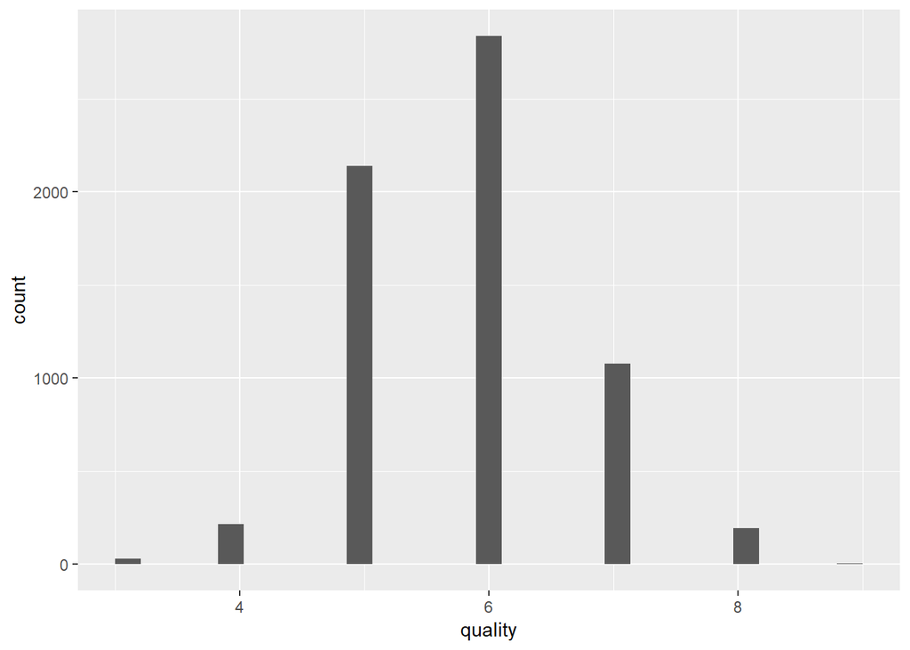

```r
ggplot(wineData, aes(quality)) + geom_histogram()
```

```r
t.test(redWineData$quality, whiteWineData$quality)
```

```
##
##  Welch Two Sample t-test
##
## data:  redWineData$quality and whiteWineData$quality
## t = -10.149, df = 2950.8, p-value < 2.2e-16
## alternative hypothesis: true difference in means is not equal to 0
## 95 percent confidence interval:
##  -0.2886173 -0.1951564
## sample estimates:
## mean of x mean of y
##  5.636023  5.877909
```

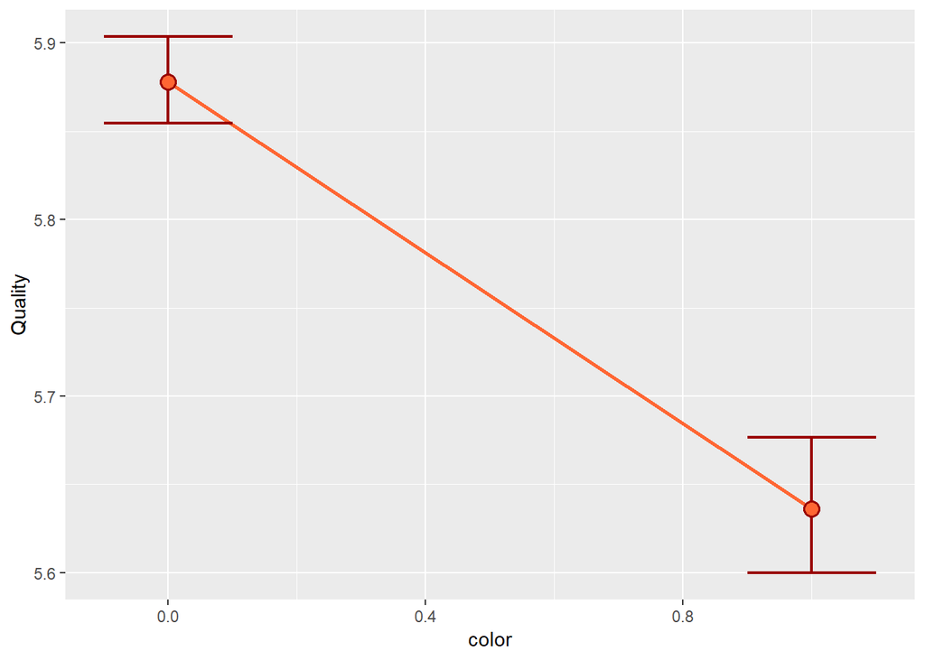

```r
line <- ggplot(wineData, aes(color, quality))
line + stat_summary(fun.y = mean, geom = "line", size = 1, aes(group=1), colour = "#FF6633") + stat_summary(fun.data = mean_cl_boot, geom = "errorbar", width = 0.2, size = 0.75, colour = "#990000") + stat_summary(fun.y = mean, geom = "point", size = 4, colour = "#990000") + stat_summary(fun.y = mean, geom = "point", size = 3, colour = "#FF6633") + labs(x = "color", y = "Quality")
```

### Assumptions for Logistic Regression

1.linearity: linear relationship between continuous predictors and the logit of the outcome variable (see section 8.8.1) 2.independence of errors: same as linear regression 3.multicollinearity: same as linear regression plus, there are some unique problems of its own: 1.incomplete information: need full combinations of variables 2.complete separation: logistic regression fails if your data does not overlap

### 5. ANOVA

assumptions 1.homogeneity of variance 2.observations are independent 3.distributions within groups are normally distributed in some cases, the assumptions don’t need to be met there are subtleties here, but in general, with equal group sizes ANOVA is robust to violations of normality homogeneity details in DSUR 10.3.2